# STAT 240 Discussion 2

## Exoplanet Data

We will be working with data on exoplanets; exoplanets are planets orbiting stars outside our Solar System. The data were pulled from the [NASA Exoplanet Archive](https://exoplanetarchive.ipac.caltech.edu/index.html) on September 12, 2022.

The variables we will be working with are defined below. If you want more details, please see the exoplanet archive [data column definitions](https://exoplanetarchive.ipac.caltech.edu/docs/API_PS_columns.html) (using the column names in the raw data).

`planet` = Planet Name `method` = Method by which the planet was first identified `year` = Discovery Year (the year it was discovered) `number` = Number of Planets `radius` = Planet Radius (units: Earth Radius) `mass` = Approximate or Minimum Planet Mass (units: Earth Mass)

## Questions

### Question 1

> Make a scatter plot with `radius` (the estimate of the planet radius) on the x-axis and `mass` (the estimate of the planet mass) on the vertical axis. The `scale_y_log10()` and `scale_y_log10()` are added to change the axis values to a `log10()` scale.

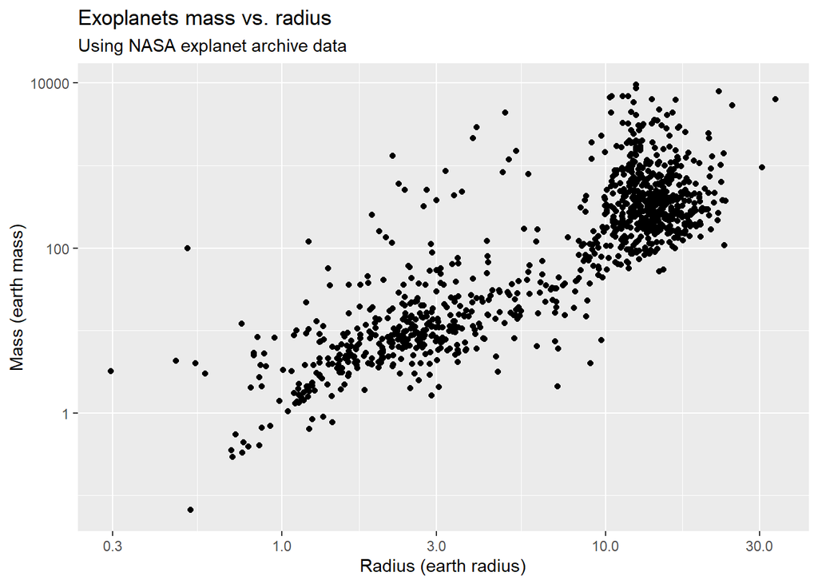

```r
## COMPLETE CODE TO MAKE THIS PLOT

ggplot(data=planets,mapping=aes(x=radius,y=mass)) +geom_point()+scale_y_log10() + scale_x_log10() +
  xlab("Radius (earth radius)") + ylab("Mass (earth mass)") +
  ggtitle("Exoplanets mass vs. radius",
          subtitle="Using NASA explanet archive data")
```

### Question 2

> Make a scatter plot like the previous problem, but add the `color` aesthetic inside the `aes()` function and set it equal to `method` (discovery method). This will color each point according to which method was used to discover it.

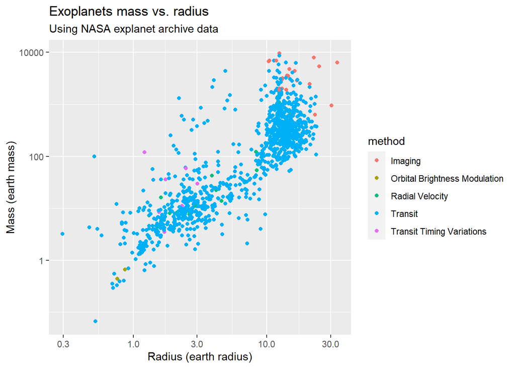

```r
## COMPLETE CODE TO MAKE THIS PLOT
ggplot(data=planets,mapping=aes(x=radius,y=mass)) +geom_point(aes(color=method)) +
  scale_y_log10() + scale_x_log10() +
  xlab("Radius (earth radius)") + ylab("Mass (earth mass)") +
  ggtitle("Exoplanets mass vs. radius",
          subtitle="Using NASA explanet archive data")
```

### Question 3

> Make a barplot counting how many planets were discovered using each method. (Hint: use `geom_bar()`, which counts the number of occurences, unlike `geom_col()`).

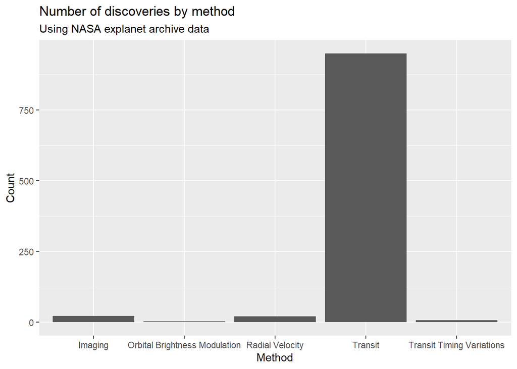

```r
## COMPLETE CODE TO MAKE THIS PLOT
ggplot(data=planets) + geom_bar(mapping=aes(x=method)) +
  xlab("Method") + ylab("Count") +
  ggtitle("Number of discoveries by method",
          subtitle="Using NASA explanet archive data")
```

### Question 4

- Which discovery method was used to detect the most exoplanets in our `planet` data frame?
- What general pattern do you notice between planet mass and radius?
- What is the estimated radius (approximately) of the most massive planet included on the plot?

### Question 5

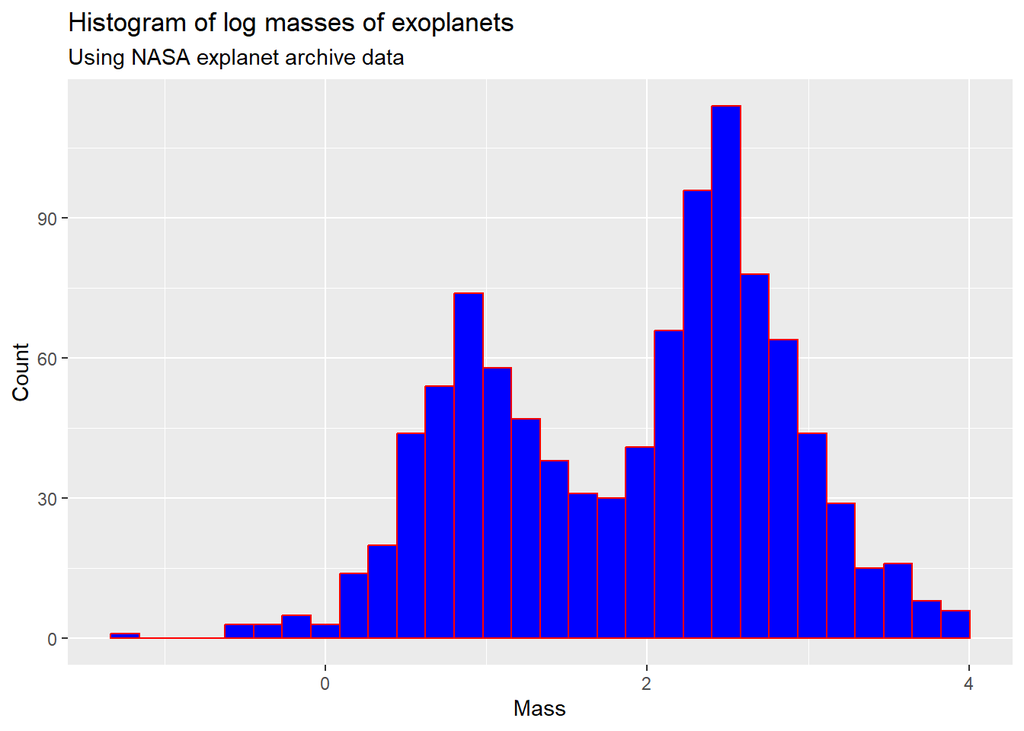

```r
## COMPLETE CODE TO MAKE THIS PLOT
ggplot(data=planets,mapping=aes(x=log10(mass))) + geom_histogram(color="red",fill="blue") +
  xlab("Mass") + ylab("Count") +
  ggtitle("Histogram of log masses of exoplanets",
          subtitle="Using NASA explanet archive data")
```